# Superstore Marketing Campaign Analysis

### Customer Segmentation & Membership Response Prediction

## Business Problem Statement

A retail superstore company wants to analyze customer purchasing behaviour, campaign engagement, and product spending patterns to improve targeted marketing strategies and increase membership acceptance rates.

The company collects customer demographic details, purchase history, website activity, and spending information across multiple product categories. However, management lacks clear insights into which customer segments contribute the most revenue and which factors influence campaign response.

This project focuses on identifying high-value customers, understanding purchasing behaviour, predicting membership acceptance, and generating data-driven recommendations using Python, SQL, and Power BI.

## Project Objectives

The primary objective of this project is to analyze customer behaviour and identify the key factors influencing membership campaign acceptance. The analysis aims to support data-driven marketing decisions and improve customer engagement strategies.

- Analyze customer demographics and purchasing behaviour
- Identify high-value and low-engagement customer segments
- Study spending patterns across multiple product categories
- Examine customer activity through web, catalog, and store purchases
- Perform exploratory data analysis (EDA) to discover hidden insights
- Build predictive models to forecast campaign response
- Create interactive dashboards using Power BI
- Generate actionable business recommendations for marketing optimization

## Dataset Description

The dataset used in this project contains customer demographic information, purchasing behaviour, product spending patterns, and campaign response details collected from a retail superstore marketing campaign. The dataset consists of **2,240** customer records and **22** attributes related to customer profile, income, purchasing channels, spending categories, website activity, and campaign acceptance behaviour. The primary goal of the dataset is to analyze customer engagement and predict whether a customer will accept the Gold Membership marketing campaign.

### Key Dataset Features

- **Customer Demographics:** Age, Education, Marital Status, Income
- **Family Information:** Kidhome, Teenhome
- **Spending Behaviour:** Wine, Meat, Fish, Fruits, Sweet, and Gold product spending
- **Purchase Channels:** Web purchases, Catalog purchases, Store purchases
- **Customer Engagement:** Website visits and Recency of purchases
- **Target Variable:** Response (Campaign Accepted or Not)

## Importing Required Libraries

The project uses Python libraries for data manipulation, visualization, statistical analysis, and machine learning.

```python
import pandas as pd
import numpy as np
import matplotlib.pyplot as plt
import seaborn as sns
```

## Data Loading

The dataset was imported into the Python environment using the Pandas library for further preprocessing and analysis.

```python
# Loading the Dataset
supermarket_data = pd.read_csv(r"C:\Users\dell\Downloads\4414699-Dataset_-_Superstore_Marketing_Campaign_Analysis\Superstore Marketing Campaign Dataset.csv")
#----------------------------------------------------------------------------------------------------------------------------------------------------------------
# Preview of Data
supermarket_data.head(5)
#----------------------------------------------------------------------
```

|  | Id | Year_Birth | Education | Marital_Status | Income | Kidhome | Teenhome | Dt_Customer | Recency | MntWines | ... | MntFishProducts | MntSweetProducts | MntGoldProds | NumDealsPurchases | NumWebPurchases | NumCatalogPurchases | NumStorePurchases | NumWebVisitsMonth | Response | Complain |
| --- | --- | --- | --- | --- | --- | --- | --- | --- | --- | --- | --- | --- | --- | --- | --- | --- | --- | --- | --- | --- | --- |
| 0 | 1826 | 1970 | Graduation | Divorced | 84835.0 | 0 | 0 | 6/16/14 | 0 | 189 | ... | 111 | 189 | 218 | 1 | 4 | 4 | 6 | 1 | 1 | 0 |
| 1 | 1 | 1961 | Graduation | Single | 57091.0 | 0 | 0 | 6/15/14 | 0 | 464 | ... | 7 | 0 | 37 | 1 | 7 | 3 | 7 | 5 | 1 | 0 |
| 2 | 10476 | 1958 | Graduation | Married | 67267.0 | 0 | 1 | 5/13/14 | 0 | 134 | ... | 15 | 2 | 30 | 1 | 3 | 2 | 5 | 2 | 0 | 0 |
| 3 | 1386 | 1967 | Graduation | Together | 32474.0 | 1 | 1 | 11/5/14 | 0 | 10 | ... | 0 | 0 | 0 | 1 | 1 | 0 | 2 | 7 | 0 | 0 |
| 4 | 5371 | 1989 | Graduation | Single | 21474.0 | 1 | 0 | 8/4/14 | 0 | 6 | ... | 11 | 0 | 34 | 2 | 3 | 1 | 2 | 7 | 1 | 0 |

5 rows × 22 columns

## Dataset Overview

Initial exploration was performed to understand dataset dimensions, column names, data types, and statistical summaries.

```python
# Dataset Dimensions
#-----------------------------------------------------------------
print("Dataset Dimensions:",supermarket_data.shape)

#-----------------------------------------------------------------
# Column Name
#-----------------------------------------------------------------
print("\nDataset columns names:",supermarket_data.columns)

#-----------------------------------------------------------------
# Information About Data
#-----------------------------------------------------------------
print("\nInformation About Data:",supermarket_data.info())

#-----------------------------------------------------------------
# Statistical Summaries
#-----------------------------------------------------------------
print("\nStatistical Summaries:",supermarket_data.describe())
```

```
Dataset Dimensions: (2240, 22)

Dataset columns names: Index(['Id', 'Year_Birth', 'Education', 'Marital_Status', 'Income', 'Kidhome',
       'Teenhome', 'Dt_Customer', 'Recency', 'MntWines', 'MntFruits',
       'MntMeatProducts', 'MntFishProducts', 'MntSweetProducts',
       'MntGoldProds', 'NumDealsPurchases', 'NumWebPurchases',
       'NumCatalogPurchases', 'NumStorePurchases', 'NumWebVisitsMonth',
       'Response', 'Complain'],
      dtype='object')
<class 'pandas.core.frame.DataFrame'>
RangeIndex: 2240 entries, 0 to 2239
Data columns (total 22 columns):
 #   Column               Non-Null Count  Dtype
---  ------               --------------  -----
 0   Id                   2240 non-null   int64
 1   Year_Birth           2240 non-null   int64
 2   Education            2240 non-null   object
 3   Marital_Status       2240 non-null   object
 4   Income               2216 non-null   float64
 5   Kidhome              2240 non-null   int64
 6   Teenhome             2240 non-null   int64
 7   Dt_Customer          2240 non-null   object
 8   Recency              2240 non-null   int64
 9   MntWines             2240 non-null   int64
 10  MntFruits            2240 non-null   int64
 11  MntMeatProducts      2240 non-null   int64
 12  MntFishProducts      2240 non-null   int64
 13  MntSweetProducts     2240 non-null   int64
 14  MntGoldProds         2240 non-null   int64
 15  NumDealsPurchases    2240 non-null   int64
 16  NumWebPurchases      2240 non-null   int64
 17  NumCatalogPurchases  2240 non-null   int64
 18  NumStorePurchases    2240 non-null   int64
 19  NumWebVisitsMonth    2240 non-null   int64
 20  Response             2240 non-null   int64
 21  Complain             2240 non-null   int64
dtypes: float64(1), int64(18), object(3)
memory usage: 385.1+ KB

Information About Data: None
```

[output cut: 35 more lines]

```
min           0.000000             0.000000           0.000000
25%           2.000000             0.000000           3.000000
50%           4.000000             2.000000           5.000000
75%           6.000000             4.000000           8.000000
max          27.000000            28.000000          13.000000

       NumWebVisitsMonth     Response     Complain
count        2240.000000  2240.000000  2240.000000
mean            5.316518     0.149107     0.009375
std             2.426645     0.356274     0.096391
min             0.000000     0.000000     0.000000
25%             3.000000     0.000000     0.000000
50%             6.000000     0.000000     0.000000
75%             7.000000     0.000000     0.000000
max            20.000000     1.000000     1.000000
```

## Missing Value Analysis

The dataset was checked for null and missing values to ensure analytical consistency and improve data quality.

```python
#--------------------------------------------
# Missing and null values
#--------------------------------------------
print("Total Missing Values:\n",supermarket_data .isnull().sum())
```

```
Total Missing Values:
 Id                      0
Year_Birth              0
Education               0
Marital_Status          0
Income                 24
Kidhome                 0
Teenhome                0
Dt_Customer             0
Recency                 0
MntWines                0
MntFruits               0
MntMeatProducts         0
MntFishProducts         0
MntSweetProducts        0
MntGoldProds            0
NumDealsPurchases       0
NumWebPurchases         0
NumCatalogPurchases     0
NumStorePurchases       0
NumWebVisitsMonth       0
Response                0
Complain                0
dtype: int64
```

## Data Cleaning

```python
# Filling Missing Values With Median
#----------------------------------------------------------------------------------
supermarket_data["Income"].fillna(supermarket_data["Income"].median(), inplace=True)

#-----------------------------------------------------------------------------------
# checking missing values
#-----------------------------------------------------------------------------------
print("MissingValues:\n",supermarket_data.isnull().sum())

#-----------------------------------------------------------------------------------
# Checking Duplicated values
#-----------------------------------------------------------------------------------
print("\nDuplicateValues:",supermarket_data.duplicated().sum())
```

```
MissingValues:
 Id                     0
Year_Birth             0
Education              0
Marital_Status         0
Income                 0
Kidhome                0
Teenhome               0
Dt_Customer            0
Recency                0
MntWines               0
MntFruits              0
MntMeatProducts        0
MntFishProducts        0
MntSweetProducts       0
MntGoldProds           0
NumDealsPurchases      0
NumWebPurchases        0
NumCatalogPurchases    0
NumStorePurchases      0
NumWebVisitsMonth      0
Response               0
Complain               0
dtype: int64

DuplicateValues: 0
```

## Date Transformation

The customer enrollment date column was converted into datetime format for temporal analysis and feature engineering.

```python
# Converting date colummn data type text to date
#-----------------------------------------------------------
supermarket_data["Dt_Customer"] = pd.to_datetime(
    supermarket_data["Dt_Customer"],
     format = "%m/%d/%y"
)
#-------------------------------------------------------------
# chechking data type
#--------------------------------------------------------------
print(supermarket_data["Dt_Customer"].dtype)
```

```
datetime64[ns]
```

## Feature Engineering

New analytical features such as Age, Total Spend, and Customer Tenure were created to improve customer behavior analysis and predictive modeling.

```python
# Creatig new columns
#--------------------------------------------------------
# Age column
#--------------------------------------------------------
supermarket_data["Age"] = 2014 - supermarket_data["Year_Birth"]

#--------------------------------------------------------
# Total Spend column
#--------------------------------------------------------
supermarket_data["Total_Spend"] = (
    supermarket_data["MntWines"] +
    supermarket_data["MntFruits"] +
    supermarket_data["MntMeatProducts"] +
    supermarket_data["MntFishProducts"] +
    supermarket_data["MntSweetProducts"] +
    supermarket_data["MntGoldProds"]
)

#-------------------------------------------------------
# Customer Tenure column
#-------------------------------------------------------
supermarket_data["Customer_Tenure"] = 2014 - supermarket_data["Dt_Customer"].dt.year
```

```python
supermarket_data.shape
```

```
(2240, 25)
```

# Exploratory Data Analysis (EDA)

Exploratory Data Analysis (EDA) was performed to understand customer demographics, purchasing behaviour, spending patterns, campaign engagement, and customer interaction trends.

The analysis helps identify meaningful business insights, customer segments, and factors influencing campaign response behaviour.

Various statistical summaries and visualizations were used to analyze relationships between income, age, purchasing channels, product spending categories, and customer engagement metrics.

# Demographic Analysis

Demographic analysis is performed to understand the customer profile based on age, education level, marital status, and income distribution. Analyzing customer demographics helps identify the characteristics of different customer groups and supports targeted marketing and customer engagement strategies.

This section focuses on understanding customer composition across different demographic factors such as age groups, educational background, marital status, and income levels.

## Age Distribution Analysis

Customer age distribution was analyzed to identify dominant age groups and understand how age influences customer purchasing behaviour and campaign response patterns.

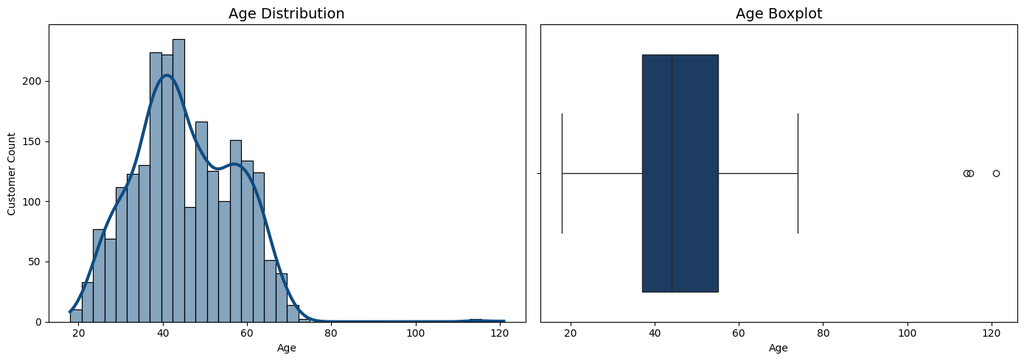

```python
fig, axes = plt.subplots(1, 2, figsize=(14,5))

# Age Distribution
sns.histplot(
    supermarket_data["Age"],
    kde=True,
    color="#0F4C81",
    line_kws = {"color":"#123B6D","linewidth":3},
    ax=axes[0]
)

axes[0].set_title("Age Distribution", fontsize=14)
axes[0].set_xlabel("Age")
axes[0].set_ylabel("Customer Count")

# Age Boxplot
sns.boxplot(
    x=supermarket_data["Age"],
    color="#123B6D",
    ax=axes[1]
)

axes[1].set_title("Age Boxplot", fontsize=14)
axes[1].set_xlabel("Age")


plt.tight_layout()
plt.show()
```

The age distribution indicates that the majority of customers fall within the middle-aged category, particularly between the age range of 35 to 60 years. The histogram shows that customer representation is strongest among mature adults, while younger and older age groups contribute comparatively less to the overall customer base.

The distribution appears moderately right-skewed, suggesting the presence of a smaller population of older customers. The boxplot further confirms this pattern and highlights a few extreme age outliers with unusually high values exceeding 100 years. These observations indicate potential inconsistencies or data quality issues in the **Year_Birth** column, which may require additional validation during the data cleaning phase.

Overall, the analysis suggests that the retailer’s customer base is dominated by middle-aged consumers, making this segment highly valuable for targeted promotions, membership campaigns, and personalized marketing strategies.

### Education and Marital Status Distribution Analysis

Demographic distribution analysis is performed to understand the educational background and marital status composition of customers. Analyzing these demographic factors helps identify the characteristics of the customer base and provides insights into customer diversity and social profiles.

This analysis helps businesses better understand their target audience and supports the development of more personalized marketing strategies, customer engagement approaches, and customer segmentation initiatives.

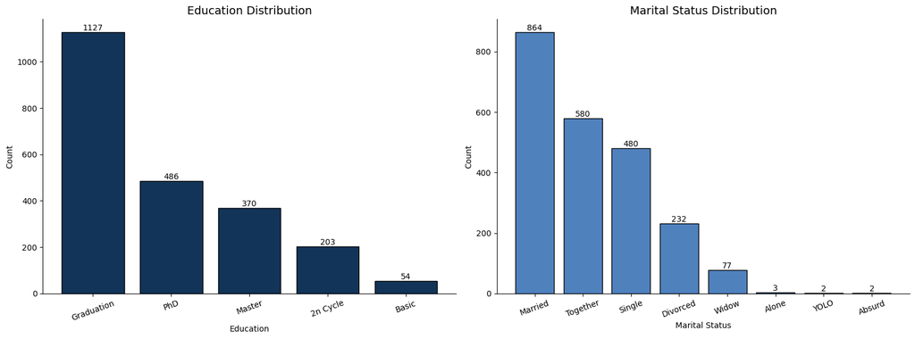

```python
# Education and Marital Status Distribution Analysis

fig, axes = plt.subplots(1, 2, figsize=(16, 6))


# Education Distribution

education_counts = supermarket_data["Education"].value_counts()

bars1 = axes[0].bar(
    education_counts.index,
    education_counts.values,
    color="#123458",
    edgecolor="black"
)

axes[0].set_title("Education Distribution", fontsize=14)
axes[0].set_xlabel("Education")
axes[0].set_ylabel("Count")
axes[0].tick_params(axis='x', rotation=20)

for bar in bars1:

    height = bar.get_height()

    axes[0].text(
        bar.get_x() + bar.get_width()/2,
        height,
        int(height),
        ha='center',
        va='bottom',
        fontsize=10
    )


# Marital Status Distribution

marital_counts = supermarket_data["Marital_Status"].value_counts()

bars2 = axes[1].bar(
    marital_counts.index,
    marital_counts.values,
    color="#4F81BD",
    edgecolor="black"
)

axes[1].set_title("Marital Status Distribution", fontsize=14)
axes[1].set_xlabel("Marital Status")
axes[1].set_ylabel("Count")
axes[1].tick_params(axis='x', rotation=20)

for bar in bars2:

    height = bar.get_height()

    axes[1].text(
        bar.get_x() + bar.get_width()/2,
        height,
        int(height),
        ha='center',
        va='bottom',
        fontsize=10
    )

sns.despine()

plt.tight_layout()

plt.show()
```

The demographic distribution analysis highlights the educational background and marital status composition of customers. Understanding these demographic characteristics helps identify the dominant customer groups and supports the development of targeted marketing strategies and personalized customer engagement approaches.

The education distribution indicates that the majority of customers belong to the Graduation category, followed by PhD and Master degree holders. This suggests that the customer base is largely composed of well-educated individuals, which may influence purchasing behaviour, campaign responsiveness, and product preferences.

The marital status distribution shows that married customers form the largest customer segment, followed by customers living together and single customers. This indicates that family-oriented and household customers contribute significantly to the business customer base.

Overall, the demographic analysis provides valuable insights into customer composition and helps businesses better understand the characteristics of their primary customer segments for more effective marketing and customer relationship strategies.

## Income Distribution Analysis

Income distribution analysis was performed to understand customer earning patterns and identify variations in purchasing power among different customer groups.

The analysis helps evaluate whether higher-income customers contribute more toward product spending and campaign engagement.

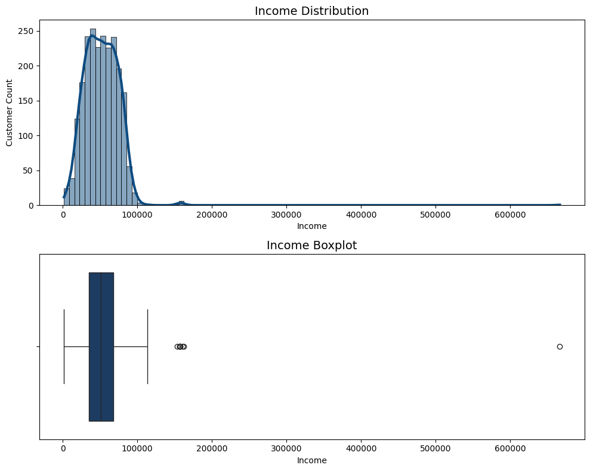

```python
# Income Distribution & Income Boxplot
# Create figure with 2 rows and 1 column
#--------------------------------------------------
fig, axes = plt.subplots(2, 1, figsize=(10,8))
#----------------------------------------------------
# Income Distribution Plot
# Histogram to understand income distribution
#-----------------------------------------------------
sns.histplot(
    supermarket_data["Income"],
    kde=True,
    color="#0F4C81",
    line_kws = {"color":"#123B6D","linewidth":3},

    ax=axes[0]
)
#---------------------------------------------------
# Title and axis labels
axes[0].set_title("Income Distribution", fontsize=14)
axes[0].set_xlabel("Income")
axes[0].set_ylabel("Customer Count")
#-----------------------------------------------------
# Income Boxplot
# Boxplot to detect spread and outliers
#-----------------------------------------------------
sns.boxplot(
    x=supermarket_data["Income"],
    color="#123B6D",
    ax=axes[1]
)

# Title and axis label
axes[1].set_title("Income Boxplot", fontsize=14)
axes[1].set_xlabel("Income")

# Adjust layout and display charts
plt.tight_layout()
plt.show()
```

The income distribution shows a strong right-skewed pattern, indicating that the majority of customers belong to the low-to-middle income segment, while a comparatively smaller group earns significantly higher income. Most customers appear concentrated within a moderate income range, suggesting that the retailer primarily serves middle-income households.

The boxplot further highlights the presence of several high-income outliers. A few customers have exceptionally large income values, extending far beyond the typical income range of the overall customer base. These premium customers may contribute disproportionately to overall sales and could represent an important segment for targeted marketing and membership campaigns.

The wide spread of income values reflects the diversity of the retailer’s customer base across different economic groups. While most customers exhibit moderate purchasing power, the existence of affluent customers creates opportunities for personalized promotions, premium product recommendations, and loyalty-based engagement strategies.

Overall, the visual analysis indicates a customer population dominated by middle-income consumers, with a smaller but strategically valuable high-income segment that may significantly influence campaign response and spending behaviour.

# Spending and Purchase Behaviour Analysis

Spending and purchase behaviour analysis is performed to understand customer purchasing patterns, product preferences, and shopping channel behaviour. This analysis helps identify how customers contribute to overall business revenue and which product categories and purchase channels generate the highest customer activity.

The analysis focuses on total customer spending, product category-wise spending patterns, and customer purchase behaviour across different purchasing channels such as web, store, and catalog purchases.

## Total Spending Analysis

Customer spending behaviour was analyzed using the Total Spend feature created during feature engineering.The analysis identifies high-value customers and evaluates overall purchasing patterns across multiple product categories.

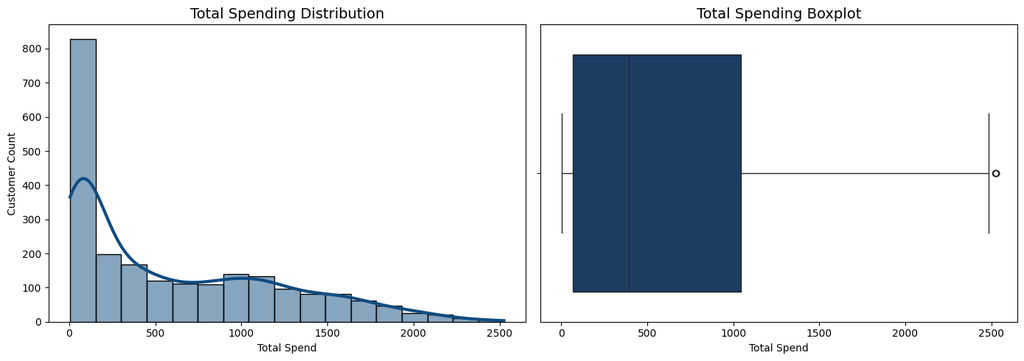

```python
# Total Spending Distribution & Boxplot

# Create figure with 1 row and 2 columns
fig, axes = plt.subplots(1, 2, figsize=(14,5))


# Total Spending Distribution

# Histogram to understand spending behaviour
sns.histplot(
    supermarket_data["Total_Spend"],
    kde=True,
    color="#0F4C81",
    line_kws={"color":"#00008B", "linewidth":3},
    ax=axes[0]
)

# Title and labels
axes[0].set_title("Total Spending Distribution", fontsize=14)
axes[0].set_xlabel("Total Spend")
axes[0].set_ylabel("Customer Count")

# Total Spending Boxplot

# Boxplot to detect outliers
sns.boxplot(
    x=supermarket_data["Total_Spend"],
    color="#123B6D",
    ax=axes[1]
)

# Title and labels
axes[1].set_title("Total Spending Boxplot", fontsize=14)
axes[1].set_xlabel("Total Spend")


# Adjust layout
plt.tight_layout()

# Show charts
plt.show()
```

The total spending analysis reveals a highly right-skewed distribution, indicating that the majority of customers spend relatively lower amounts, while a smaller segment contributes significantly higher spending values. Most customers are concentrated within the lower spending range, suggesting that regular or moderate buyers form the core customer base of the retailer.

The histogram shows a gradual decline in customer frequency as total spending increases, highlighting the presence of fewer high-spending customers. This pattern is commonly observed in retail businesses, where a limited number of premium customers contribute disproportionately to overall revenue generation.

The wide spread in spending behaviour also reflects the diversity of purchasing habits among customers. While many customers make occasional or moderate purchases, a smaller premium segment demonstrates consistently higher spending activity across product categories.

Overall, the analysis suggests that the retailer’s revenue is influenced by both a large base of moderate spenders and a smaller group of high-value customers. This creates opportunities for customer segmentation, personalized promotions, premium membership targeting, and loyalty-driven marketing strategies.

## Product Category Spending Analysis

Spending patterns across different product categories such as Wines, Meat Products, Fruits, Fish Products, Sweets, and Gold Products were analyzed to identify the most preferred customer product segments.

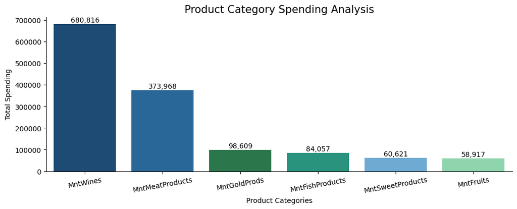

```python
# Product Category Spending Analysis

# Calculate total spending for each category
category_spending = supermarket_data[[
    "MntWines",
    "MntMeatProducts",
    "MntGoldProds",
    "MntFishProducts",
    "MntSweetProducts",
    "MntFruits"
]].sum().sort_values(ascending=False)


# Custom professional colors
custom_colors = [
    "#0F4C81",
    "#1769AA",
    "#1E8449",
    "#17A589",
    "#5DADE2",
    "#82E0AA"
]


# Create figure
plt.figure(figsize=(12,4))

# Barplot
sns.barplot(
    x=category_spending.index,
    y=category_spending.values,
    hue=category_spending.index,
    palette=custom_colors,
    legend=False
)

# Add values on bars
for index, value in enumerate(category_spending.values):
    plt.text(
        index,
        value + 10000,
        f"{value:,.0f}",
        ha='center',
        fontsize=10
    )

# Title and labels
plt.title("Product Category Spending Analysis", fontsize=15)
plt.xlabel("Product Categories")
plt.ylabel("Total Spending")

# Rotate x labels
plt.xticks(rotation=10)

# Remove top and right borders
sns.despine()

# Show chart
plt.show()
```

The product category spending analysis reveals significant differences in customer purchasing behaviour across product categories. Among all categories, **Wine Products** generated the highest total spending by a substantial margin, making it the dominant revenue-contributing category for the retailer. This indicates strong customer preference and high purchasing frequency within the wine segment.

**Meat Products** emerged as the second-highest spending category, although total expenditure remains considerably lower compared to wines. The strong performance of these two categories suggests that customers are willing to spend more on premium and lifestyle-oriented products, highlighting their importance in overall business profitability.

The remaining categories, including **Gold Products**, **Fish Products**, **Sweet Products**, and **Fruits**, contribute relatively smaller portions of total spending. While these categories generate lower revenue individually, they still play an important role in maintaining product diversity and supporting cross-category purchasing behaviour among customers.

The noticeable gap between top-performing and low-performing categories indicates unequal customer demand across product segments. This creates opportunities for the retailer to design category-specific promotional campaigns, personalized recommendations, and cross-selling strategies to improve engagement in underperforming categories.

Overall, the analysis suggests that customer spending is heavily concentrated in a few major product categories, particularly Wines and Meat Products. These categories represent critical drivers of sales performance and should remain a strategic focus for inventory planning, loyalty programs, and future marketing initiatives.

## Purchase Channel Analysis

Customer purchasing behaviour was evaluated across multiple purchase channels including website purchases, catalog purchases, and in-store purchases.

The objective was to identify the most frequently used purchasing platform and understand customer shopping preferences.

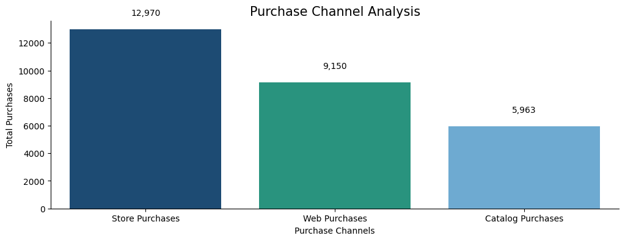

```python
# Purchase Channel Analysis

# Calculate total purchases across channels
channel_purchases = supermarket_data[[
    "NumWebPurchases",
    "NumCatalogPurchases",
    "NumStorePurchases"
]].sum().sort_values(ascending=False)


# Custom colors
channel_colors = [
    "#0F4C81",
    "#17A589",
    "#5DADE2"
]


# Create figure
plt.figure(figsize=(12,4))

# Barplot
sns.barplot(
    x=channel_purchases.index,
    y=channel_purchases.values,
    hue=channel_purchases.index,
    palette=channel_colors,
    legend=False
)

# Add values on bars
for index, value in enumerate(channel_purchases.values):
    plt.text(
        index,
        value + 1000,
        f"{value:,.0f}",
        ha='center',
        fontsize=10
    )

# Title and labels
plt.title("Purchase Channel Analysis", fontsize=15)
plt.xlabel("Purchase Channels")
plt.ylabel("Total Purchases")

# Rename labels
plt.xticks(
    ticks=[0,1,2],
    labels=["Store Purchases", "Web Purchases", "Catalog Purchases"]
)

# Remove top and right borders
sns.despine()

# Show chart
plt.show()
```

The purchase channel analysis highlights customer buying behaviour across different purchasing platforms, including physical stores, web platforms, and catalog purchases. The visualization clearly shows that **Store Purchases** contribute the highest number of transactions, making physical retail stores the dominant purchase channel for the company.

The strong performance of store purchases suggests that customers continue to prefer in-person shopping experiences, where they can directly explore products and make immediate purchasing decisions. This indicates that physical retail locations remain a major driver of customer engagement and sales performance.

**Web Purchases** represent the second-largest transaction channel, demonstrating significant customer adoption of online shopping platforms. The relatively high volume of web transactions indicates growing digital engagement and highlights the importance of maintaining a strong online presence and personalized digital marketing strategies.

**Catalog Purchases** contribute the lowest number of transactions among all purchase channels. Although this channel generates comparatively lower customer activity, it may still serve niche customer segments who prefer traditional purchasing methods or promotional catalogs.

The variation in purchase behaviour across channels reflects the diverse shopping preferences of customers. Some customers prefer convenience-driven online purchases, while others continue to rely on traditional in-store shopping experiences. Understanding these channel preferences can help the company optimize marketing campaigns, improve customer targeting, and allocate business resources more effectively.

## Customer Engagement Analysis

Customer engagement metrics such as website visits and recency of purchases were analyzed to evaluate customer activity levels and interaction patterns with the business.

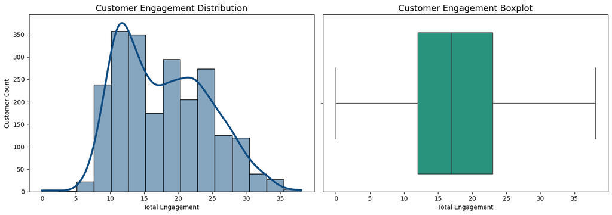

```python
# Customer Engagement Analysis

# Create Customer Engagement feature
supermarket_data["Total_Engagement"] = (
    supermarket_data["NumWebPurchases"] +
    supermarket_data["NumCatalogPurchases"] +
    supermarket_data["NumStorePurchases"] +
    supermarket_data["NumWebVisitsMonth"]
)


# Create figure with 1 row and 2 columns
fig, axes = plt.subplots(1, 2, figsize=(14,5))


# Engagement Distribution

# Histogram
sns.histplot(
    supermarket_data["Total_Engagement"],
    bins = 15,
    kde=True,
    color="#0F4C81",
    line_kws={"color":"#00008B", "linewidth":3},
    ax=axes[0]
)

# Title and labels
axes[0].set_title("Customer Engagement Distribution", fontsize=14)
axes[0].set_xlabel("Total Engagement")
axes[0].set_ylabel("Customer Count")


# Engagement Boxplot

# Boxplot
sns.boxplot(
    x=supermarket_data["Total_Engagement"],
    color="#17A589",
    ax=axes[1]
)

# Title and labels
axes[1].set_title("Customer Engagement Boxplot", fontsize=14)
axes[1].set_xlabel("Total Engagement")


# Adjust layout
plt.tight_layout()

# Show charts
plt.show()
```

The customer engagement analysis evaluates how actively customers interact with the retailer across different purchasing and digital channels. The Total Engagement feature combines store purchases, web purchases, catalog purchases, and monthly website visits to measure overall customer activity and engagement behaviour.

The histogram indicates that the majority of customers fall within the moderate engagement range, particularly between engagement scores of **10 to 25** . This suggests that most customers maintain regular interaction with the company through purchasing activity and website engagement, forming a stable and active customer base.

The distribution appears slightly **right-skewed**, indicating the presence of a smaller group of highly engaged customers with significantly higher interaction levels. These customers are likely to represent loyal or premium customer segments who frequently interact with the company across multiple channels.

The boxplot further confirms that customer engagement levels are relatively balanced, with no excessive extreme outliers observed in the dataset. The median engagement lies within the moderate range, suggesting that average customer interaction behaviour remains consistent across the majority of the customer base.

The presence of highly engaged customers creates valuable opportunities for loyalty programs, personalized recommendations, premium membership campaigns, and retention-focused marketing strategies. At the same time, customers with lower engagement levels may require targeted promotional efforts to increase activity and improve long-term customer relationships.

Overall, the analysis suggests that the retailer maintains a moderately engaged customer base with a smaller segment of highly active customers contributing significantly to overall interaction and business performance.

# Campaign Response Analysis

Campaign response analysis is performed to evaluate customer reactions toward marketing campaigns and promotional offers. The analysis focuses on identifying differences between customers who accepted the campaign and those who did not respond positively to the offer.

This section helps understand customer response behaviour, campaign effectiveness, customer spending differences, and engagement patterns associated with marketing campaign acceptance.

## Campaign Response Analysis

The campaign response analysis examines the number of customers who accepted and rejected the marketing campaign offer.This analysis helps measure customer engagement and evaluate campaign effectiveness.

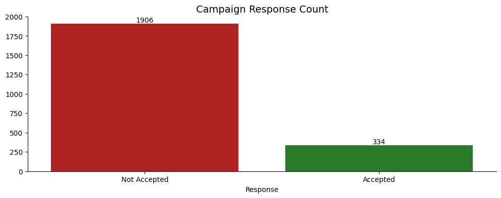

```python
# Campaign Response Count Plot
#---------------------------------------
plt.figure(figsize=(12,4))
sns.countplot(
    x="Response",
    data=supermarket_data,
    hue="Response",
    palette=["#C60C0C","#1E871B"],
    legend=False
)

# Add numbers on bars
for container in plt.gca().containers:
    plt.bar_label(container)

# Title and labels
plt.title("Campaign Response Count", fontsize=14)
plt.xlabel("Response")
plt.ylabel("")



# Rename x-axis values
plt.xticks([0,1], ["Not Accepted", "Accepted"])

sns.despine()

# Show chart
plt.show()
```

The campaign response analysis shows a significant imbalance between customers who accepted the Gold Membership offer and those who did not. A very large proportion of customers rejected the campaign, while only a comparatively smaller segment responded positively to the offer.

The visual clearly indicates that the current marketing campaign achieved limited conversion success. Although the campaign successfully reached a broad customer base, only a small percentage of customers demonstrated interest in accepting the membership program. This suggests that the campaign may not have been sufficiently personalized or targeted toward the most responsive customer groups.

The low acceptance count highlights the importance of customer segmentation and behavioural analysis. Factors such as income level, spending behaviour, purchase frequency, web engagement, and product preferences may strongly influence campaign acceptance rates. Identifying these patterns can help the company improve future marketing effectiveness.

The accepted customer segment, despite being smaller in size, may represent highly valuable customers with stronger purchasing intent and higher engagement levels. These customers can be further analyzed to design targeted retention strategies, premium offers, and loyalty-based campaigns.

Overall, the analysis suggests that the majority of customers are currently resistant to the membership offer, creating an opportunity for the retailer to refine campaign targeting, improve promotional strategies, and enhance customer engagement to increase future conversion rates.

### Customer Response Behaviour Analysis

This section analyzes the behavioural differences between customers who accepted and those who did not accept the marketing campaign offer. The objective of this analysis is to identify the customer characteristics associated with positive campaign response.

Comparative visualizations are created using barplots and boxplots for important business variables such as Income, Total Spend, Total Engagement, and Number of Web Purchases. The barplots help compare average customer behaviour across both groups, while the boxplots provide insights into data distribution, spending variability, and customer activity patterns.

This analysis helps evaluate whether high-income, high-spending, highly engaged, and digitally active customers are more likely to respond positively to marketing campaigns.

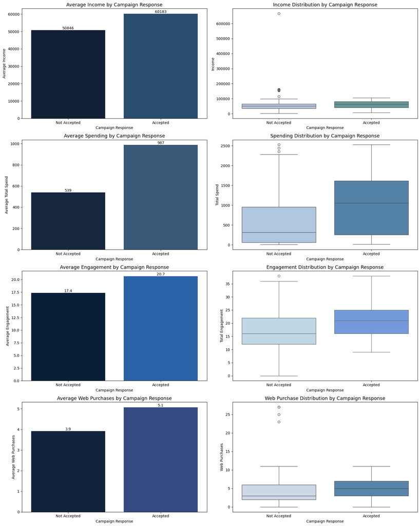

```python
# Response-Based Comparative Analysis
# Create figure with 4 rows and 2 columns
fig, axes = plt.subplots(4, 2, figsize=(16,20))
#-------------------------------------------------------
# Response vs Income
#-------------------------------------------------------
# Barplot
sns.barplot(
    x="Response",
    y="Income",
    data=supermarket_data,
    hue="Response",
    palette=["#0B1F3A", "#1F4E79"],
    errorbar=None,
    legend=False,
    ax=axes[0,0]
)
# Add values on bars
for container in axes[0,0].containers:
    axes[0,0].bar_label(container, fmt="%.0f")

# Title and Labels
axes[0,0].set_title("Average Income by Campaign Response", fontsize=13)
axes[0,0].set_xlabel("Campaign Response")
axes[0,0].set_ylabel("Average Income")

# Rename x-axis labels
axes[0,0].set_xticks([0,1])
axes[0,0].set_xticklabels(["Not Accepted", "Accepted"])
#-------------------------------------------------------------------------------------------------
# Boxplot
sns.boxplot(
    x="Response",
    y="Income",
    data=supermarket_data,
    hue="Response",
    palette=["#B0C4DE", "#5F9EA0"],
    legend=False,
    ax=axes[0,1]
)

# Title and Labels
axes[0,1].set_title("Income Distribution by Campaign Response", fontsize=13)
axes[0,1].set_xlabel("Campaign Response")
axes[0,1].set_ylabel("Income")

# Rename x-axis labels
axes[0,1].set_xticks([0,1])
axes[0,1].set_xticklabels(["Not Accepted", "Accepted"])
#---------------------------------------------------------------------------------------------------
# ---------------------------------------------------------
# Response vs Total Spend
# ---------------------------------------------------------
# Barplot
sns.barplot(
    x="Response",
    y="Total_Spend",
    data=supermarket_data,
    hue="Response",
    palette=["#102542", "#2E5984"],
    errorbar=None,
    legend=False,
    ax=axes[1,0]
)
# Add values on bars
for container in axes[1,0].containers:
    axes[1,0].bar_label(container, fmt="%.0f")

# Title and Labels
axes[1,0].set_title("Average Spending by Campaign Response", fontsize=13)
axes[1,0].set_xlabel("Campaign Response")
axes[1,0].set_ylabel("Average Total Spend")

# Rename x-axis labels
axes[1,0].set_xticks([0,1])
axes[1,0].set_xticklabels(["Not Accepted", "Accepted"])
#--------------------------------------------------------------------------------------------------
# Boxplot
sns.boxplot(
    x="Response",
    y="Total_Spend",
    data=supermarket_data,
    hue="Response",
    palette=["#A7C7E7", "#4682B4"],
    legend=False,
    ax=axes[1,1]
)

# Title and Labels
axes[1,1].set_title("Spending Distribution by Campaign Response", fontsize=13)
axes[1,1].set_xlabel("Campaign Response")
axes[1,1].set_ylabel("Total Spend")

# Rename x-axis labels
axes[1,1].set_xticks([0,1])
axes[1,1].set_xticklabels(["Not Accepted", "Accepted"])
#----------------------------------------------------------------------------------------------
# ---------------------------------------------------------
# Response vs Total Engagement
# ---------------------------------------------------------
# Barplot
sns.barplot(
    x="Response",
    y="Total_Engagement",
    data=supermarket_data,
    hue="Response",
    palette=["#001F3F", "#1560BD"],
    errorbar=None,
    legend=False,
    ax=axes[2,0]
)

# Add values on bars
for container in axes[2,0].containers:
    axes[2,0].bar_label(container, fmt="%.1f")

# Title and Labels
axes[2,0].set_title("Average Engagement by Campaign Response", fontsize=13)
axes[2,0].set_xlabel("Campaign Response")
axes[2,0].set_ylabel("Average Engagement")

# Rename x-axis labels
axes[2,0].set_xticks([0,1])
axes[2,0].set_xticklabels(["Not Accepted", "Accepted"])
#--------------------------------------------------------------------------------------------------------------
# Boxplot
sns.boxplot(
    x="Response",
    y="Total_Engagement",
    data=supermarket_data,
    hue="Response",
    palette=["#B9D9EB", "#6495ED"],
    legend=False,
    ax=axes[2,1]
)

# Title and Labels
axes[2,1].set_title("Engagement Distribution by Campaign Response", fontsize=13)
axes[2,1].set_xlabel("Campaign Response")
axes[2,1].set_ylabel("Total Engagement")

# Rename x-axis labels
axes[2,1].set_xticks([0,1])
axes[2,1].set_xticklabels(["Not Accepted", "Accepted"])
#---------------------------------------------------------------------------------------------------------------
# ---------------------------------------------------------
# Response vs Web Purchases
# ---------------------------------------------------------
# Barplot
sns.barplot(
    x="Response",
    y="NumWebPurchases",
    data=supermarket_data,
    hue="Response",
    palette=["#0A2342", "#274690"],
    errorbar=None,
    legend=False,
    ax=axes[3,0]
)

# Add values on bars
for container in axes[3,0].containers:
    axes[3,0].bar_label(container, fmt="%.1f")

# Title and Labels
axes[3,0].set_title("Average Web Purchases by Campaign Response", fontsize=13)
axes[3,0].set_xlabel("Campaign Response")
axes[3,0].set_ylabel("Average Web Purchases")

# Rename x-axis labels
axes[3,0].set_xticks([0,1])
axes[3,0].set_xticklabels(["Not Accepted", "Accepted"])
#-------------------------------------------------------------------------------------------------------------
# Boxplot
sns.boxplot(
    x="Response",
    y="NumWebPurchases",
    data=supermarket_data,
    hue="Response",
    palette=["#C9D6EA", "#4B86B4"],
    legend=False,
    ax=axes[3,1]
)

# Title and Labels
axes[3,1].set_title("Web Purchase Distribution by Campaign Response", fontsize=13)
axes[3,1].set_xlabel("Campaign Response")
axes[3,1].set_ylabel("Web Purchases")

# Rename x-axis labels
axes[3,1].set_xticks([0,1])
axes[3,1].set_xticklabels(["Not Accepted", "Accepted"])


# Adjust Layout
plt.tight_layout()
# Show Charts
plt.show()
```

The comparative analysis between customers who accepted and did not accept the marketing campaign reveals clear behavioural differences across income, spending, engagement, and web purchasing activity.

The income analysis shows that customers who accepted the campaign have a noticeably higher average income compared to customers who rejected the offer. The boxplot further confirms that the accepted customer segment generally belongs to a higher income range, although a few extreme income outliers are also present in the dataset.

A significant difference can also be observed in total spending behaviour. Customers who accepted the campaign spend considerably more on average, indicating that high-value customers are more likely to respond positively to marketing offers. The spending distribution also highlights a broader range of spending behaviour among accepted customers, including several premium spenders.

The customer engagement analysis demonstrates that accepted customers show higher interaction levels across multiple activities such as purchases, website visits, and overall engagement metrics. This suggests that highly engaged customers are more responsive to promotional campaigns and marketing communication.

Similarly, web purchase analysis indicates that customers who make more online purchases are more likely to accept the campaign offer. The higher average number of web purchases among accepted customers suggests that digitally active customers represent an important target segment for future campaigns.

Overall, the analysis strongly suggests that campaign acceptance is closely associated with customer value, purchasing behaviour, and engagement activity. Customers who accepted the campaign tend to be higher-income, high-spending, highly engaged, and digitally active customers. These insights can help the company improve customer targeting strategies and design more effective personalized marketing campaigns.

## Correlation Analysis

Correlation analysis was performed to identify relationships between customer demographics, spending behaviour, purchasing channels, and campaign response variables.

The analysis helps uncover important factors influencing customer engagement and spending behaviour.

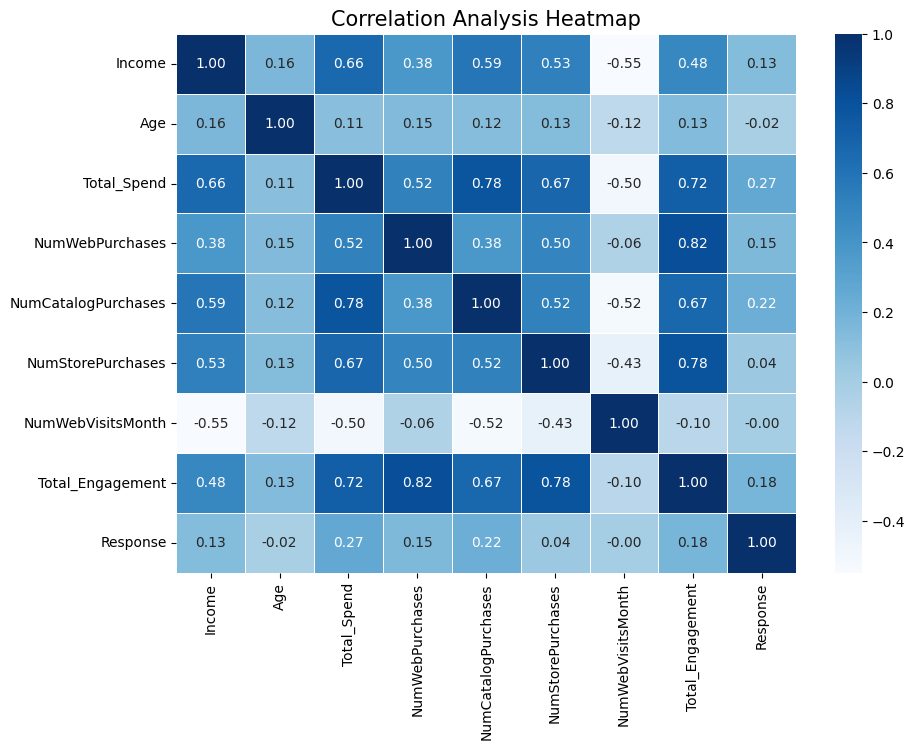

```python
# Correlation Analysis
# Select numerical columns for correlation
#------------------------------------------------------------------------------------
correlation_columns = [
    "Income",
    "Age",
    "Total_Spend",
    "NumWebPurchases",
    "NumCatalogPurchases",
    "NumStorePurchases",
    "NumWebVisitsMonth",
    "Total_Engagement",
    "Response"
]
#-----------------------------------------------------------------------------------------
# Calculate correlation matrix
corr_matrix = supermarket_data[correlation_columns].corr()
#------------------------------------------------------------------------------------------
# Create figure
plt.figure(figsize=(10,7))
#------------------------------------------------------------------------------------------
# Heatmap
sns.heatmap(
    corr_matrix,
    annot=True,
    cmap="Blues",
    fmt=".2f",
    linewidths=0.5
)
#---------------------------------------------------------------------------------------------
# Title
plt.title("Correlation Analysis Heatmap", fontsize=15)
#---------------------------------------------------------------------------------------------
# Show chart
plt.show()
#----------------------------------------------------------------------------------------------
```

The correlation analysis was performed to understand the relationships between customer demographics, purchasing behaviour, engagement activity, and campaign response variables. The heatmap provides a clear overview of both positive and negative relationships among important numerical features in the dataset.

The analysis reveals a strong positive correlation between **Total Spending** and purchase-related variables such as **NumCatalogPurchases**, **NumStorePurchases**, and **Total Engagement**. This indicates that customers who actively purchase across multiple channels generally contribute significantly higher overall spending.

**Total Engagement** shows a particularly strong positive relationship with **NumWebPurchases** and **NumStorePurchases**, suggesting that highly engaged customers interact more frequently with the company through both online and offline purchasing channels. These customers may represent loyal and high-value customer segments.

The heatmap also shows that **Income** has a moderate positive correlation with **Total Spending** and purchasing activity. This suggests that customers with higher income levels tend to spend more and participate more actively in purchasing behaviour, making them important targets for premium membership and personalized marketing campaigns.

A noticeable negative relationship is observed between **NumWebVisitsMonth** and certain purchasing variables such as **Total Spending** and **Catalog Purchases**. This may indicate that customers who frequently browse the website do not always convert into active buyers, highlighting potential opportunities to improve website conversion strategies and customer engagement funnels.

The **Response** variable shows relatively weaker correlations with most features, suggesting that campaign acceptance behaviour is influenced by multiple combined factors rather than a single dominant variable. This indicates that customer response prediction may require the integration of demographic, behavioural, and engagement-related variables together for more effective analysis.

Overall, the correlation analysis provides valuable insights into customer purchasing patterns, engagement behaviour, and spending relationships. These findings can support customer segmentation, predictive modeling, campaign optimization, and strategic business decision-making processes.

# Statistical Hypothesis Testing

After performing exploratory and comparative analysis, statistical hypothesis testing is conducted to validate whether the observed differences between customer groups are statistically significant. The purpose of this analysis is to determine whether customer income, spending behaviour, engagement activity, and purchasing patterns have a meaningful relationship with campaign response behaviour.

Statistical tests help support business conclusions using mathematical evidence rather than relying only on visual observations. This section includes hypothesis testing techniques to evaluate relationships between important customer behaviour variables and campaign acceptance.

### Research Question

Do customers who accepted the marketing campaign spend significantly more compared to customers who did not accept the campaign?

```python
# Independent T-Test for Total Spending
# Import statistical library
from scipy.stats import ttest_ind
#---------------------------------------------------
# Create two groups based on campaign response
#----------------------------------------------------------------------------------------
accepted_customers = supermarket_data[supermarket_data["Response"] == 1]["Total_Spend"]

not_accepted_customers = supermarket_data[supermarket_data["Response"] == 0]["Total_Spend"]
#-----------------------------------------------------------------------------------------
# Perform Independent T-Test
#-----------------------------------------------------------------------------------------
t_statistic, p_value = ttest_ind(
    accepted_customers,
    not_accepted_customers
)
#------------------------------------------------------------------------------------------
print("T-Statistic :", round(t_statistic, 3))
print("P-Value :", round(p_value, 5))
#--------------------------------------------------------------------------------------------
# Hypothesis Decision
#--------------------------------------------------------------------------------------------
alpha = 0.05

if p_value < alpha:
    print("\nReject the Null Hypothesis")
    print("Customers who accepted the campaign spend significantly more.")

else:
    print("\nFail to Reject the Null Hypothesis")
    print("No significant spending difference exists between the two groups.")
#-----------------------------------------------------------------------------------------------
```

```
T-Statistic : 13.017
P-Value : 0.0

Reject the Null Hypothesis
Customers who accepted the campaign spend significantly more.
```

### T-Test Results and Interpretation

An Independent T-Test was performed to determine whether customers who accepted the marketing campaign spend significantly more compared to customers who did not accept the campaign.

The test produced a T-Statistic value of **13.017** and a P-Value smaller than **0.05**. Since the p-value is significantly lower than the chosen significance level, the null hypothesis is rejected.

The results indicate that there is a statistically significant difference in spending behaviour between customers who accepted the campaign and those who did not. Customers who accepted the campaign tend to spend considerably more on average, suggesting that campaign responders represent higher-value customers for the business.

This finding highlights the importance of targeting high-spending and highly engaged customers in future marketing campaigns to improve campaign effectiveness and overall business profitability.

### Research Question

Is there a statistically significant relationship between customer income and total spending behaviour?

```python
# Correlation Test Between Income and Total Spending
# Import statistical library
from scipy.stats import pearsonr
#-------------------------------------------------------------
# Perform Pearson Correlation Test
correlation_coefficient, p_value = pearsonr(
    supermarket_data["Income"],
    supermarket_data["Total_Spend"]
)
#---------------------------------------------------------------
print("Correlation Coefficient :", round(correlation_coefficient, 3))
print("P-Value :", round(p_value, 5))
#----------------------------------------------------------------
# Hypothesis Decision
alpha = 0.05

if p_value < alpha:
    print("\nReject the Null Hypothesis")
    print("A statistically significant relationship exists between Income and Total Spending.")

else:
    print("\nFail to Reject the Null Hypothesis")
    print("No statistically significant relationship exists between Income and Total Spending.")
```

```
Correlation Coefficient : 0.665
P-Value : 0.0

Reject the Null Hypothesis
A statistically significant relationship exists between Income and Total Spending.
```

### Correlation Test Results and Interpretation

A Pearson Correlation Test was performed to evaluate the relationship between customer income and total spending behaviour.

The analysis produced a correlation coefficient value of **0.665**, indicating a strong positive relationship between Income and Total Spending. This suggests that customers with higher income levels generally tend to spend more on products and services.

The test also generated a p-value smaller than **0.05**, indicating that the relationship between income and spending behaviour is statistically significant. Therefore, the null hypothesis is rejected.

These findings suggest that customer income plays an important role in influencing purchasing behaviour and overall spending patterns. Higher-income customers represent valuable customer segments and may respond more effectively to premium product offerings, personalized marketing strategies, and loyalty-based campaigns.

### Research Question

Is customer campaign response significantly associated with education level?

```python
# Chi-Square Test Between Education and Campaign Response
# Import libraries
from scipy.stats import chi2_contingency
#-------------------------------------------------------------
# Create contingency table
contingency_table = pd.crosstab(
    supermarket_data["Education"],
    supermarket_data["Response"]
)
#-------------------------------------------------------------
# Perform Chi-Square Test
chi2_statistic, p_value, dof, expected = chi2_contingency(
    contingency_table
)
#---------------------------------------------------------------
print("Chi-Square Statistic :", round(chi2_statistic, 3))
print("P-Value :", round(p_value, 5))
#---------------------------------------------------------------
# Hypothesis Decision

alpha = 0.05

if p_value < alpha:
    print("\nReject the Null Hypothesis")
    print("Campaign response is significantly associated with education level.")

else:
    print("\nFail to Reject the Null Hypothesis")
    print("No significant association exists between education level and campaign response.")
```

```
Chi-Square Statistic : 23.076
P-Value : 0.00012

Reject the Null Hypothesis
Campaign response is significantly associated with education level.
```

### Chi-Square Test Results and Interpretation

A Chi-Square Test of Independence was performed to evaluate whether customer campaign response is significantly associated with education level.

The test produced a Chi-Square Statistic value of **23.076** and a P-Value of **0.00012**. Since the p-value is significantly lower than the chosen significance level of 0.05, the null hypothesis is rejected.

The results indicate that a statistically significant association exists between customer education level and campaign response behaviour. This suggests that customers from different educational backgrounds respond differently to marketing campaigns and promotional offers.

These findings can help the company better understand customer segments and design more targeted marketing strategies based on education-related customer behaviour patterns. Personalized communication and campaign customization for specific education groups may improve campaign effectiveness and customer conversion rates.

# Customer Segmentation Analysis using RFM Model

Customer segmentation analysis using the RFM model is performed to understand customer purchasing behaviour and identify valuable customer groups based on customer activity and spending patterns. The RFM model helps businesses classify customers according to their recency, purchase frequency, and monetary contribution.

RFM analysis supports customer retention strategies, personalized marketing initiatives, customer relationship management, and targeted business decision-making by identifying high-value and highly engaged customer groups.

### RFM Metric Preparation

RFM metric preparation is performed to create the three important customer behaviour metrics used in RFM analysis: Recency, Frequency, and Monetary value. These metrics help evaluate customer purchasing activity, engagement level, and overall business contribution.

Recency measures how recently a customer made a purchase, Frequency represents the total number of purchases made by the customer, and Monetary value indicates the total amount spent by the customer.

Since the dataset contains one summarized record for each customer instead of transaction-level purchase history, purchase frequency is calculated using the total number of purchases made across different purchasing channels, including web purchases, catalog purchases, and store purchases. This aggregated purchase behaviour is used as a proxy for customer purchase frequency in the RFM analysis process.

```python
# Create Frequency Metric
#-------------------------------------------------------------------------------
supermarket_data["Frequency"] = (
    supermarket_data["NumWebPurchases"] +
    supermarket_data["NumCatalogPurchases"] +
    supermarket_data["NumStorePurchases"]
)
#-------------------------------------------------------------------------------
# Create Monetary Metric
supermarket_data["Monetary"] = supermarket_data["Total_Spend"]
#-------------------------------------------------------------------------------
# Display First Five Rows
supermarket_data[[
    "Recency",
    "Frequency",
    "Monetary"

]].head()
#--------------------------------------------------------------------------------
```

|  | Recency | Frequency | Monetary |
| --- | --- | --- | --- |
| 0 | 0 | 14 | 1190 |
| 1 | 0 | 17 | 577 |
| 2 | 0 | 10 | 251 |
| 3 | 0 | 3 | 11 |
| 4 | 0 | 6 | 91 |

### RFM Score Calculation

RFM scoring is performed to rank customers according to recency, purchase frequency, and monetary value. Customers are assigned scores based on their purchasing behaviour and overall business contribution.

The scoring process helps identify highly active customers, loyal customers, and high-spending customer groups for effective customer segmentation and targeted marketing strategies.

```python
# Recency Score
#------------------------------------------------------------------------
supermarket_data["R_Score"] = pd.qcut(
    supermarket_data["Recency"],
    q = 4,
    labels = [4, 3, 2, 1]
)
#-----------------------------------------------------------------------
# Frequency Score
supermarket_data["F_Score"] = pd.qcut(
    supermarket_data["Frequency"].rank(method="first"),
    q = 4,
    labels = [1, 2, 3, 4]
)
#------------------------------------------------------------------------
# Monetary Score
supermarket_data["M_Score"] = pd.qcut(
    supermarket_data["Monetary"].rank(method="first"),
    q = 4,
    labels = [1, 2, 3, 4]
)
#------------------------------------------------------------------------
# Create Combined RFM Score
supermarket_data["RFM_Score"] = (
    supermarket_data["R_Score"].astype(str) +
    supermarket_data["F_Score"].astype(str) +
    supermarket_data["M_Score"].astype(str)
)
#-------------------------------------------------------------------------
# Display First Five Rows
supermarket_data[[
    "Recency",
    "Frequency",
    "Monetary",
    "RFM_Score"

]].head()
```

|  | Recency | Frequency | Monetary | RFM_Score |
| --- | --- | --- | --- | --- |
| 0 | 0 | 14 | 1190 | 434 |
| 1 | 0 | 17 | 577 | 433 |
| 2 | 0 | 10 | 251 | 422 |
| 3 | 0 | 3 | 11 | 411 |
| 4 | 0 | 6 | 91 | 412 |

### RFM-Based Customer Segmentation

RFM-based customer segmentation is performed to classify customers according to their purchasing behaviour, customer activity, and overall business value. Customers are grouped into different customer segments based on their recency, purchase frequency, and monetary contribution.

This segmentation helps identify highly valuable customers, loyal customers, potential customers, and customers who may require re-engagement strategies for improved customer retention and business growth.

```python
# Create RFM Customer Segments
#----------------------------------------------------------------------------------------------------------
def customer_segment(row):
    if row["R_Score"] >= 4 and row["F_Score"] >= 4:
        return "Champions"
    elif row["F_Score"] >= 3 and row["M_Score"] >= 3:
        return "Loyal Customers"
    elif row["R_Score"] >= 3 and row["F_Score"] >= 2:
        return "Potential Customers"
    else:
        return "At Risk Customers"
#------------------------------------------------------------------------------------------------------------
# Apply Segmentation
supermarket_data["RFM_Segment"] = supermarket_data.apply(customer_segment,axis = 1)
#-------------------------------------------------------------------------------------------------------------
# Display Segment Counts
supermarket_data["RFM_Segment"].value_counts()
#-------------------------------------------------------------------------------------------------------------
```

```
RFM_Segment
Loyal Customers        941
At Risk Customers      878
Potential Customers    278
Champions              143
Name: count, dtype: int64
```

### RFM Customer Segment Distribution Analysis

RFM customer segment distribution analysis is performed to understand how customers are distributed across different customer value groups. The analysis highlights the proportion of champions, loyal customers, potential customers, and at-risk customers within the customer base.

Understanding customer segment distribution supports customer targeting strategies, customer retention initiatives, and personalized marketing approaches based on customer purchasing behaviour and engagement patterns.

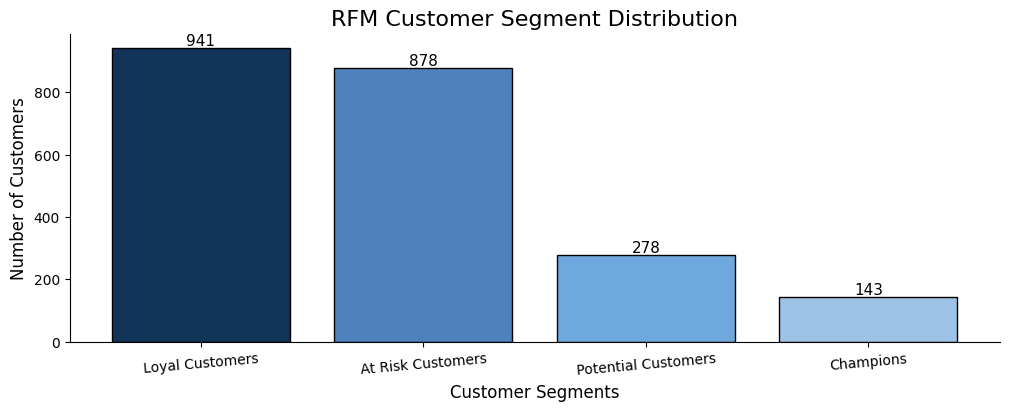

```python
# RFM Customer Segment Distribution Analysis
#-----------------------------------------------------------------------------------------
segment_counts = supermarket_data["RFM_Segment"].value_counts()
#-----------------------------------------------------------------------------------------
plt.figure(figsize=(12,4))
bars = plt.bar(
    segment_counts.index,
    segment_counts.values,
    color = [
        "#123458",
        "#4F81BD",
        "#6FA8DC",
        "#9DC3E6"
    ],
    edgecolor = "black"
)
#-------------------------------------------------------------------------------------------
# Add Values on Bars
for bar in bars:
    height = bar.get_height()
    plt.text(
        bar.get_x() + bar.get_width()/2,
        height,
        int(height),
        ha = "center",
        va = "bottom",
        fontsize = 11
    )
#--------------------------------------------------------------------------------------------
plt.title("RFM Customer Segment Distribution",fontsize = 16)
plt.xlabel("Customer Segments",fontsize = 12)
plt.ylabel("Number of Customers",fontsize = 12)
plt.xticks(rotation=5)
sns.despine()
#---------------------------------------------------------------------------------------------
plt.show()
#---------------------------------------------------------------------------------------------
```

- Loyal Customers represent the largest customer segment, indicating strong customer engagement and stable purchasing behaviour.
- A significant proportion of customers are categorized as At Risk Customers, highlighting the need for customer retention and re-engagement strategies.
- Potential Customers show moderate engagement levels and can be converted into loyal customers through targeted marketing initiatives.
- Champions represent the smallest but most valuable customer segment with strong purchasing activity and high business contribution.

### Revenue Contribution by RFM Segment

Revenue contribution analysis by RFM segment is performed to evaluate the overall spending contribution of different customer groups. This analysis helps identify which customer segments generate the highest business revenue and contribute most significantly to overall business performance.

Analyzing revenue contribution patterns helps businesses understand the financial importance of different customer segments and supports customer retention strategies, targeted marketing initiatives, and customer relationship management decisions.

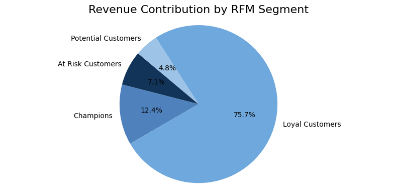

```python
# Revenue Contribution by RFM Segment
#-------------------------------------------------------------------------------------------
segment_revenue = supermarket_data.groupby("RFM_Segment")["Monetary"].sum()
#-------------------------------------------------------------------------------------------
plt.figure(figsize=(8,4))
#-------------------------------------------------------------------------------------------
plt.pie(
    segment_revenue.values,
    labels = segment_revenue.index,
    autopct = "%1.1f%%",
    startangle = 140,
    colors = [
        "#123458",
        "#4F81BD",
        "#6FA8DC",
        "#9DC3E6"
    ]
)
#--------------------------------------------------------------------------------------------
plt.title("Revenue Contribution by RFM Segment",fontsize = 16)
#--------------------------------------------------------------------------------------------
# Keep Pie Chart Circular and Centered
plt.axis('equal')
plt.tight_layout()
#---------------------------------------------------------------------------------------------
plt.show()
#---------------------------------------------------------------------------------------------
```

The revenue contribution analysis shows that Loyal Customers contribute the largest share of overall business revenue, accounting for approximately **75.7%** of total revenue contribution. This indicates that consistently engaged customers play a major role in overall business profitability and revenue generation.

Champions contribute a significant portion of revenue despite representing a smaller customer segment, highlighting the importance of highly valuable and highly engaged customers for business growth. At Risk Customers and Potential Customers contribute comparatively lower revenue shares, suggesting opportunities for customer retention strategies and targeted marketing initiatives to improve customer engagement and purchasing behaviour.

### Average Monetary Value by RFM Segment

Average monetary value analysis is performed to compare the average customer spending across different RFM customer segments. This analysis helps identify which customer groups contribute higher average spending and generate greater business value.

Understanding average spending behaviour across customer segments supports customer targeting strategies, personalized marketing initiatives, and customer retention planning by identifying high-value customer groups with strong purchasing activity.

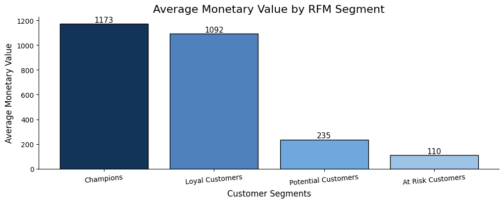

```python
# Average Monetary Value by RFM Segment
#---------------------------------------------------------------------------------------------------------------
avg_monetary = supermarket_data.groupby("RFM_Segment")["Monetary"].mean().sort_values(ascending=False)
#---------------------------------------------------------------------------------------------------------------
plt.figure(figsize=(12,4))
#----------------------------------------------------------------------------------------------------------------
bars = plt.bar(
    avg_monetary.index,
    avg_monetary.values,
    color = [
        "#123458",
        "#4F81BD",
        "#6FA8DC",
        "#9DC3E6"
    ],
    edgecolor = "black"
)
#--------------------------------------------------------------------------------------------------------------------
# Add Values on Bars
for bar in bars:
    height = bar.get_height()
    plt.text(
        bar.get_x() + bar.get_width()/2,
        height,
        f"{height:.0f}",
        ha = "center",
        va = "bottom",
        fontsize = 11
    )
#---------------------------------------------------------------------------------------------------------------------
plt.title("Average Monetary Value by RFM Segment",fontsize = 16)
plt.xlabel("Customer Segments",fontsize = 12)
plt.ylabel("Average Monetary Value",fontsize = 12)
sns.despine()
plt.xticks(rotation=5)
#-----------------------------------------------------------------------------------------------------------------------
plt.show()
#------------------------------------------------------------------------------------------------------------------------
```

The average monetary value analysis shows that Champions have the highest average spending value among all customer segments, indicating that this customer group contributes significantly to overall business profitability through high purchasing activity and strong customer engagement.

Loyal Customers also demonstrate a high average monetary value, highlighting their importance as a stable and consistently revenue-generating customer segment. In comparison, Potential Customers and At Risk Customers show considerably lower average spending levels, suggesting opportunities for targeted promotional strategies, customer retention initiatives, and customer engagement campaigns to improve purchasing behaviour and increase customer value.

### Recency vs Monetary Analysis by Customer Segment

Recency vs Monetary analysis is performed to examine the relationship between customer recency and customer spending behaviour across different RFM customer segments. The scatter plot helps visualize customer purchasing activity and spending patterns based on customer recency levels.

The analysis highlights how recently active customers contribute to overall business revenue and helps identify valuable customer groups with high spending behaviour and strong customer engagement. Different customer segments are visually distinguished to better understand customer distribution patterns and purchasing characteristics.

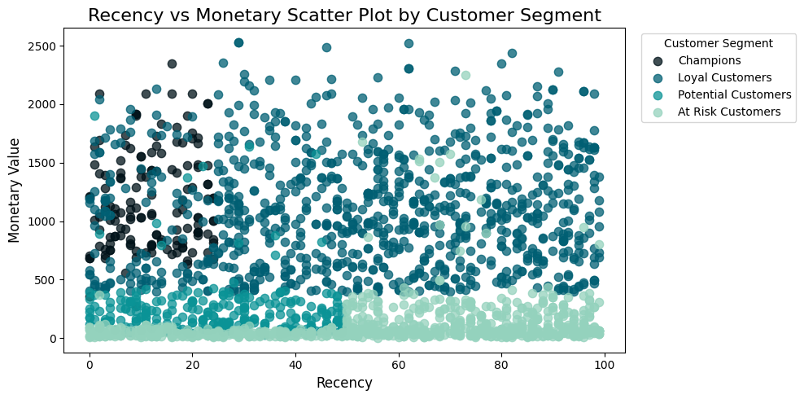

```python
# Recency vs Monetary Scatter Plot by Customer Segment
#-------------------------------------------------------------------------------------
segment_colors = {
    "Champions": "#001219",
    "Loyal Customers": "#005F73",
    "Potential Customers": "#0A9396",
    "At Risk Customers": "#94D2BD"
}
fig, ax = plt.subplots(figsize=(10,5))
#--------------------------------------------------------------------------------------
for segment, color in segment_colors.items():
    segment_data = supermarket_data[
        supermarket_data["RFM_Segment"] == segment
    ]
    ax.scatter(
        segment_data["Recency"],
        segment_data["Monetary"],
        label = segment,
        color = color,
        alpha = 0.75,
        s = 55
    )
#---------------------------------------------------------------------------------------
ax.set_title(
    "Recency vs Monetary Scatter Plot by Customer Segment",
    fontsize = 16
)
ax.set_xlabel(
    "Recency",
    fontsize = 12
)
ax.set_ylabel(
    "Monetary Value",
    fontsize = 12
)
ax.legend(
    title = "Customer Segment",
    bbox_to_anchor = (1.02, 1),
    loc = "upper left"
)
plt.tight_layout()
plt.show()
#-------------------------------------------------------------------------------------------
```

The Recency vs Monetary scatter plot illustrates the relationship between customer recency and customer spending behaviour across different RFM customer segments. The visualization shows that Champion Customers and Loyal Customers are associated with comparatively higher monetary values, indicating stronger purchasing activity and higher business contribution.

Potential Customers demonstrate moderate spending behaviour with varying recency levels, suggesting opportunities for customer engagement and conversion into higher-value customer groups. In contrast, At Risk Customers are concentrated in lower monetary value regions with higher recency levels, indicating reduced customer engagement and lower recent purchasing activity. The overall distribution highlights distinct customer behaviour patterns across different customer segments and supports targeted customer retention and marketing strategies.

### Pareto Analysis

Pareto analysis is performed to examine the relationship between customer contribution and overall business revenue using the Pareto Principle, also known as the 80/20 rule. The analysis helps identify whether a smaller percentage of customers contributes a larger proportion of total business revenue.

The cumulative revenue curve helps visualize customer revenue concentration patterns and supports strategic business decision-making, customer retention strategies, and targeted marketing initiatives focused on high-value customer groups.

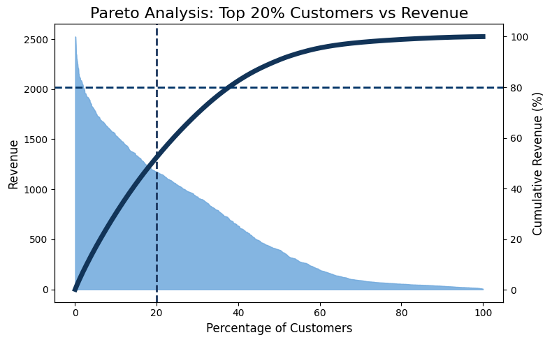

```python
# Pareto Analysis
# Sort Customers by Monetary Value
#----------------------------------------------------------------------------------------------------------
pareto_df = supermarket_data.sort_values(by = "Monetary",ascending = False).reset_index(drop=True)
#----------------------------------------------------------------------------------------------------------
# Calculate Cumulative Revenue Percentage
pareto_df["Cumulative_Revenue"] = (pareto_df["Monetary"].cumsum() / pareto_df["Monetary"].sum()) * 100
#-----------------------------------------------------------------------------------------------------------
# Calculate Customer Percentage
pareto_df["Customer_Percentage"] = ((pareto_df.index + 1) / len(pareto_df)) * 100
#----------------------------------------------------------------------------------------------------------
# Create Figure
fig, ax1 = plt.subplots(figsize=(8,5))
#----------------------------------------------------------------------------------------------------------
# Revenue Area Plot
ax1.fill_between(
    pareto_df["Customer_Percentage"],
    pareto_df["Monetary"],
    color = "#6FA8DC",
    alpha = 0.85
)
#-----------------------------------------------------------------------------------------------------------
ax1.set_xlabel("Percentage of Customers",fontsize = 12)
ax1.set_ylabel("Revenue",fontsize = 12)
#------------------------------------------------------------------------------------------------------------
# Secondary Axis
ax2 = ax1.twinx()
#------------------------------------------------------------------------------------------------------------
# Cumulative Revenue Line
ax2.plot(
    pareto_df["Customer_Percentage"],
    pareto_df["Cumulative_Revenue"],
    color = "#123458",
    linewidth = 5
)
#--------------------------------------------------------------------------------------------------------------
# 80 Percent Reference Line
ax2.axhline(
    y = 80,
    color = "#003366",
    linestyle = "--",
    linewidth = 2
)
#----------------------------------------------------------------------------------------------------------------
# 20 Percent Customer Line
ax1.axvline(
    x = 20,
    color = "#1B365D",
    linestyle = "--",
    linewidth = 2
)
#-----------------------------------------------------------------------------------------------------------------
ax2.set_ylabel("Cumulative Revenue (%)",fontsize = 12)
plt.title("Pareto Analysis: Top 20% Customers vs Revenue",fontsize = 16)
plt.tight_layout()
#------------------------------------------------------------------------------------------------------------------
plt.show()
#------------------------------------------------------------------------------------------------------------------
```

The analysis highlights the importance of retaining highly valuable customers, as a limited group of customers contributes the majority of business revenue. The gradual flattening of the cumulative revenue curve after the initial stages indicates that the remaining customer groups contribute comparatively smaller revenue shares. These findings support the need for targeted customer retention strategies, personalized marketing efforts, and focused engagement initiatives for high-value customer segments.

# Predictive Modeling for Campaign Response Analysis

Predictive modeling is performed to analyze and predict customer campaign response behaviour using machine learning classification techniques. The objective of this analysis is to identify whether a customer is likely to accept a marketing campaign based on demographic characteristics, purchasing behaviour, customer engagement patterns, and spending activity.

The Response variable is used as the target variable for classification modeling. Multiple machine learning models are developed and evaluated to understand customer response behaviour and identify the most effective predictive model for campaign response analysis.

Predictive modeling helps businesses improve targeted marketing strategies, optimize customer engagement efforts, increase campaign effectiveness, and support data-driven decision-making processes.

### Feature Selection for Predictive Modeling

Feature selection is performed to identify the most relevant variables influencing customer campaign response behaviour. Appropriate feature selection helps improve model performance, reduce unnecessary complexity, and enhance the overall predictive capability of machine learning models.

Customer demographic information, purchasing behaviour, customer engagement metrics, spending activity, and RFM-related features are selected as independent variables for classification modeling. The Response variable is used as the target variable to predict whether a customer is likely to accept a marketing campaign.

```python
# Select Features and Target Variable
#---------------------------------------------------------
X = supermarket_data[[
    "Income",
    "Age",
    "Total_Spend",
    "Total_Engagement",
    "Recency",
    "Frequency",
    "Monetary"
]]
#----------------------------------------------------------
y = supermarket_data["Response"]
#----------------------------------------------------------
# Display Feature Variables
X.head()
#-----------------------------------------------------------
```

|  | Income | Age | Total_Spend | Total_Engagement | Recency | Frequency | Monetary |
| --- | --- | --- | --- | --- | --- | --- | --- |
| 0 | 84835.0 | 44 | 1190 | 15 | 0 | 14 | 1190 |
| 1 | 57091.0 | 53 | 577 | 22 | 0 | 17 | 577 |
| 2 | 67267.0 | 56 | 251 | 12 | 0 | 10 | 251 |
| 3 | 32474.0 | 47 | 11 | 10 | 0 | 3 | 11 |
| 4 | 21474.0 | 25 | 91 | 13 | 0 | 6 | 91 |

### Train-Test Split

Train-test splitting is performed to divide the dataset into training and testing subsets for machine learning model development and evaluation. The training dataset is used to train classification models, while the testing dataset is used to evaluate model performance on unseen data.

This process helps assess the generalization capability of predictive models and ensures that model evaluation is performed using independent testing data. An 80:20 split ratio is used, where 80% of the data is allocated for training and 20% for testing.

```python
# Import Train-Test Split
#---------------------------------------------------------------
from sklearn.model_selection import train_test_split
#---------------------------------------------------------------
# Split Dataset
#---------------------------------------------------------------
X_train, X_test, y_train, y_test = train_test_split(
    X,
    y,
    test_size = 0.2,
    random_state = 42
)
#---------------------------------------------------------------
# Display Shape
#---------------------------------------------------------------
print("Training Features Shape :", X_train.shape)

print("Testing Features Shape :", X_test.shape)

print("Training Target Shape :", y_train.shape)

print("Testing Target Shape :", y_test.shape)
#--------------------------------------------------------------
```

```
Training Features Shape : (1792, 7)
Testing Features Shape : (448, 7)
Training Target Shape : (1792,)
Testing Target Shape : (448,)
```

### Logistic Regression Model

Logistic Regression is a supervised machine learning classification algorithm used to predict binary outcomes based on independent variables. In this analysis, Logistic Regression is applied to predict customer campaign response behaviour using demographic characteristics, customer engagement metrics, spending activity, and purchasing behaviour.

The model estimates the probability of whether a customer is likely to accept or reject a marketing campaign. Logistic Regression is widely used for classification problems due to its interpretability, efficiency, and ability to model binary target variables effectively.

```python
# Import Logistic Regression
#-----------------------------------------------------------
from sklearn.linear_model import LogisticRegression
#-----------------------------------------------------------
# Create Model
logistic_model = LogisticRegression(
    max_iter = 1000
)
#-----------------------------------------------------------
# Train Model
logistic_model.fit(
    X_train,
    y_train
)
#-----------------------------------------------------------
# Predict Test Data
y_pred_logistic = logistic_model.predict(
    X_test
)
#-------------------------------------------------------------
print("Logistic Regression Model Trained Successfully")
#-------------------------------------------------------------
```

```
Logistic Regression Model Trained Successfully
```

### Logistic Regression Model Evaluation

Model evaluation is performed to assess the predictive performance and classification capability of the Logistic Regression model on unseen testing data. Evaluation metrics help measure the accuracy and effectiveness of the model in predicting customer campaign response behaviour.

Classification metrics such as accuracy score, confusion matrix, and classification report are used to evaluate model performance. These metrics help analyze prediction quality, classification errors, and the overall effectiveness of the predictive model.

```python
# Import Evaluation Metrics
#-----------------------------------------------------
from sklearn.metrics import (
    accuracy_score,
    confusion_matrix,
    classification_report
)
#-----------------------------------------------------
# Accuracy Score
logistic_accuracy = accuracy_score(
    y_test,
    y_pred_logistic
)
#------------------------------------------------------
print("Logistic Regression Accuracy :",
    round(logistic_accuracy * 100, 2),
    "%"
)
#------------------------------------------------------
# Confusion Matrix
print("\nConfusion Matrix :\n")

print(confusion_matrix(
        y_test,
        y_pred_logistic
    )
)
#--------------------------------------------------------
# Classification Report
print("\nClassification Report :\n")

print(classification_report(
        y_test,
        y_pred_logistic
    )
)
#----------------------------------------------------------
```

```
Logistic Regression Accuracy : 83.48 %

Confusion Matrix :

[[366  10]
 [ 64   8]]

Classification Report :

              precision    recall  f1-score   support

           0       0.85      0.97      0.91       376
           1       0.44      0.11      0.18        72

    accuracy                           0.83       448
   macro avg       0.65      0.54      0.54       448
weighted avg       0.79      0.83      0.79       448
```

#### Key Insights

The Logistic Regression model achieved an overall classification accuracy of 83.48%, indicating that the model performs reasonably well in predicting customer campaign response behaviour. The confusion matrix shows that the model correctly classified a large proportion of customers who did not respond to the campaign.

However, the classification report indicates comparatively lower prediction performance for customers who accepted the campaign. The lower recall score for the positive response class suggests that the dataset contains class imbalance, where non-responding customers significantly outnumber responding customers. This imbalance affects the model’s ability to accurately identify campaign-accepting customers.

Overall, the Logistic Regression model demonstrates satisfactory baseline predictive performance and provides useful insights into customer response behaviour, while also highlighting the importance of handling class imbalance in predictive modeling.

### Decision Tree Model

Decision Tree is a supervised machine learning classification algorithm that predicts outcomes by splitting the dataset into different decision nodes based on feature values. The model creates a tree-like structure to classify customer campaign response behaviour using customer demographic information, purchasing activity, spending behaviour, and engagement metrics.

Decision Tree models are widely used because they are easy to interpret, capable of handling non-linear relationships, and useful for identifying important decision-making patterns influencing customer response behaviour.

```python
# Import Decision Tree Classifier
#------------------------------------------------------
from sklearn.tree import DecisionTreeClassifier
#------------------------------------------------------
# Create Decision Tree Model
decision_tree_model = DecisionTreeClassifier(
    random_state = 42
)
#------------------------------------------------------
# Train Model
decision_tree_model.fit(
    X_train,
    y_train
)
#------------------------------------------------------
# Predict Test Data
y_pred_tree = decision_tree_model.predict(
    X_test
)
#------------------------------------------------------
print("Decision Tree Model Trained Successfully")
#------------------------------------------------------
```

```
Decision Tree Model Trained Successfully
```

### Decision Tree Model Evaluation

Model evaluation is performed to assess the predictive performance of the Decision Tree classification model on unseen testing data. Evaluation metrics help measure the effectiveness of the model in predicting customer campaign response behaviour and identifying customer response patterns.

Accuracy score, confusion matrix, and classification report are used to evaluate the classification capability of the Decision Tree model and analyze prediction performance across different customer response categories.

```python
# Accuracy Score
#-------------------------------------------
decision_tree_accuracy = accuracy_score(
    y_test,
    y_pred_tree
)
#-------------------------------------------
print("Decision Tree Accuracy :",
    round(decision_tree_accuracy * 100, 2),
    "%"
)
#-------------------------------------------
# Confusion Matrix
print("\nConfusion Matrix :\n")

print(confusion_matrix(
        y_test,
        y_pred_tree
    )
)
#--------------------------------------------
# Classification Report
print("\nClassification Report :\n")

print(classification_report(
        y_test,
        y_pred_tree
    )
)
#---------------------------------------------
```

```
Decision Tree Accuracy : 78.35 %

Confusion Matrix :

[[328  48]
 [ 49  23]]

Classification Report :

              precision    recall  f1-score   support

           0       0.87      0.87      0.87       376
           1       0.32      0.32      0.32        72

    accuracy                           0.78       448
   macro avg       0.60      0.60      0.60       448
weighted avg       0.78      0.78      0.78       448
```

#### Key Insights

The Decision Tree model achieved an overall classification accuracy of 78.35%, which is slightly lower than the Logistic Regression model. However, the model demonstrated improved prediction capability for customers who accepted the marketing campaign, as indicated by the higher recall score for the positive response class.

The confusion matrix shows that the Decision Tree model was able to identify a larger number of campaign-accepting customers compared to the Logistic Regression model. This indicates that the model captures non-linear customer behaviour patterns more effectively and improves the detection of positive customer responses.

Although the overall accuracy decreased slightly, the improved recall performance for campaign responders suggests that the Decision Tree model may provide better practical value for targeted marketing and customer response prediction tasks.

### Random Forest Model

Random Forest is an ensemble machine learning classification algorithm that combines multiple decision trees to improve predictive performance and reduce overfitting. The model generates predictions by aggregating the outputs of several decision trees, resulting in more stable and accurate classification performance.

In this analysis, the Random Forest model is used to predict customer campaign response behaviour based on customer demographics, purchasing behaviour, spending activity, engagement metrics, and RFM-related features. Random Forest models are widely used because of their robustness, ability to capture complex relationships, and strong predictive capability in classification problems.

```python
# Import Random Forest Classifier
#--------------------------------------------------------
from sklearn.ensemble import RandomForestClassifier
#--------------------------------------------------------
# Create Random Forest Model
random_forest_model = RandomForestClassifier(
    n_estimators = 100,
    random_state = 42
)
#--------------------------------------------------------
# Train Model
random_forest_model.fit(
    X_train,
    y_train
)
#--------------------------------------------------------
# Predict Test Data
y_pred_rf = random_forest_model.predict(

    X_test
)
#--------------------------------------------------------
print("Random Forest Model Trained Successfully")
#--------------------------------------------------------
```

```
Random Forest Model Trained Successfully
```

### Random Forest Model Evaluation

Model evaluation is performed to assess the predictive performance and classification capability of the Random Forest model on unseen testing data. Evaluation metrics help determine how effectively the model predicts customer campaign response behaviour and identifies customer response patterns.

Accuracy score, confusion matrix, and classification report are used to evaluate the overall classification performance of the Random Forest model and compare its predictive capability with other machine learning models developed in this analysis.

```python
# Accuracy Score
#--------------------------------------------------
random_forest_accuracy = accuracy_score(
    y_test,
    y_pred_rf
)
#--------------------------------------------------
print("Random Forest Accuracy :",
    round(random_forest_accuracy * 100, 2),
    "%"
)
#--------------------------------------------------
# Confusion Matrix
print("\nConfusion Matrix :\n")

print(confusion_matrix(
        y_test,
        y_pred_rf
    )
)
#--------------------------------------------------
# Classification Report
#--------------------------------------------------
print("\nClassification Report :\n")

print(classification_report(
        y_test,
        y_pred_rf
    )
)
#---------------------------------------------------
```

```
Random Forest Accuracy : 82.81 %

Confusion Matrix :

[[356  20]
 [ 57  15]]

Classification Report :

              precision    recall  f1-score   support

           0       0.86      0.95      0.90       376
           1       0.43      0.21      0.28        72

    accuracy                           0.83       448
   macro avg       0.65      0.58      0.59       448
weighted avg       0.79      0.83      0.80       448
```

#### Key Insights

The Random Forest model achieved an overall classification accuracy of 82.81%, demonstrating strong predictive performance for customer campaign response analysis. The model effectively classified a large proportion of customers who did not respond to the marketing campaign while also improving the prediction capability for campaign-accepting customers compared to the Logistic Regression model.

The classification report shows that the Random Forest model achieved a better balance between overall accuracy and positive response prediction performance. The recall score for campaign-accepting customers improved compared to Logistic Regression, indicating that the ensemble learning approach captures customer response patterns more effectively.

### Model Comparison Analysis

Model comparison analysis is performed to evaluate and compare the predictive performance of multiple machine learning classification models developed for customer campaign response prediction. Logistic Regression, Decision Tree, and Random Forest models are compared based on their classification accuracy and ability to identify customer response behaviour.

Comparing multiple predictive models helps identify the most effective classification technique for marketing campaign response analysis and supports better model selection for business decision-making and customer targeting strategies.

```python
# Create Model Comparison DataFrame
#------------------------------------------
model_comparison = pd.DataFrame({
    "Model": [
        "Logistic Regression",
        "Decision Tree",
        "Random Forest"
    ],

    "Accuracy": [
        logistic_accuracy * 100,
        decision_tree_accuracy * 100,
        random_forest_accuracy * 100
    ]
})
#-------------------------------------------
# Display Model Comparison
model_comparison
#-------------------------------------------
```

|  | Model | Accuracy |
| --- | --- | --- |
| 0 | Logistic Regression | 83.482143 |
| 1 | Decision Tree | 78.348214 |
| 2 | Random Forest | 82.812500 |

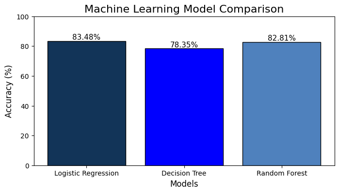

```python
# Model Comparison Visualization
#--------------------------------------------
plt.figure(figsize=(8, 4))
#--------------------------------------------
bars = plt.bar(
    model_comparison["Model"],
    model_comparison["Accuracy"],
    color = [
        "#123458",
        "blue",
        "#4F81BD"
    ],

    edgecolor = "black"
)
#---------------------------------------------
# Add Accuracy Labels
#---------------------------------------------
for bar in bars:
    height = bar.get_height()
    plt.text(
        bar.get_x() + bar.get_width()/2,
        height,
        f"{height:.2f}%",
        ha = "center",
        va = "bottom",
        fontsize = 11
    )
#----------------------------------------------
plt.title(
    "Machine Learning Model Comparison",
    fontsize = 16
)
#----------------------------------------------
plt.xlabel(
    "Models",
    fontsize = 12
)
#----------------------------------------------
plt.ylabel(
    "Accuracy (%)",
    fontsize = 12
)
#----------------------------------------------
plt.ylim(0, 100)

plt.show()
#----------------------------------------------
```

### Overall Predictive Modeling Insights

The predictive modeling analysis demonstrates that machine learning techniques can effectively predict customer campaign response behaviour using customer demographic characteristics, purchasing activity, engagement metrics, spending behaviour, and RFM-related features.

The analysis also highlighted the presence of class imbalance within the dataset, where non-responding customers significantly outnumber responding customers. This imbalance affected the prediction performance of positive campaign responses and influenced the classification behaviour of machine learning models.

Overall, the predictive modeling results provide valuable business insights for targeted marketing, customer segmentation, campaign optimization, and customer engagement strategies. The findings support data-driven decision-making and help identify customers with a higher probability of responding positively to marketing campaigns.

```python
# Saved dataset for build interactive dashboard in power bi
#-------------------------------------------------------------
supermarket_data.to_csv(
    "cleaned_supermarket_data.csv",
    index=False
)
#-------------------------------------------------------------
```

# Overall Business Insights

**1. Income is a key driver of customer spending.**  
Pearson Correlation Analysis revealed a statistically significant positive relationship between customer income and total spending. Customers with higher income levels tend to spend more, making them valuable targets for premium marketing campaigns.

**2. Campaign responders represent high-value customers.**  
The Independent T-Test confirmed that customers who accepted the marketing campaign spend significantly more than those who did not respond. This indicates that campaign responders contribute greater revenue and business value.

**3. Education level influences campaign response behavior.**  
The Chi-Square Test identified a significant association between education level and campaign response. Customers from different educational backgrounds exhibit different response patterns toward promotional campaigns.

**4. Physical stores remain the most important sales channel.**  
Purchase Channel Analysis showed that store purchases generate the highest number of transactions, followed by web purchases and catalog purchases. Physical stores continue to play a major role in overall business performance.

**5. Digital channels offer strong growth opportunities.**  
Web purchases account for a significant share of customer transactions, indicating increasing customer engagement through online channels. Strengthening digital marketing efforts can further improve sales performance.

**6. Most customers demonstrate moderate engagement levels.**  
Customer Engagement Analysis revealed that the majority of customers maintain moderate interaction levels through purchases and website visits, while a smaller group of highly engaged customers represents a valuable business segment.

**7. Customer purchasing behavior is relatively balanced.**  
Purchase Distribution Analysis showed that most customers make a moderate number of purchases, while only a limited group exhibits exceptionally high purchasing activity.

**8. RFM analysis successfully identified valuable customer segments.**  
Customers were segmented into Champions, Loyal Customers, Potential Customers, and At-Risk Customers. Champions and Loyal Customers represent the most profitable customer groups and should receive priority attention.

**9. Some customers are at risk of disengagement.**  
The presence of At-Risk Customers indicates declining engagement and purchasing activity. These customers may require targeted retention campaigns to prevent churn.

**11. Predictive analytics can improve campaign effectiveness.**  
The machine learning models successfully predicted customer campaign response, demonstrating the value of data-driven targeting and customer selection strategies.

**12. Combining segmentation and predictive modeling creates significant business value.**  
The integration of RFM segmentation and machine learning enables the business to identify high-value customers, improve campaign targeting, enhance customer retention, and maximize marketing return on investment.

# Business Recommendations

**1. Prioritize High-Income Customer Segments**  
Since income shows a strong positive relationship with customer spending, the company should focus premium membership programs, personalized offers, and exclusive promotions on high-income customers to maximize revenue generation.

**2. Increase Targeted Campaigns for High-Spending Customers**  
Statistical testing revealed that campaign responders spend significantly more than non-responders. Future marketing campaigns should target customers with higher spending behavior to improve campaign conversion rates and return on marketing investment.

**3. Develop Education-Based Marketing Strategies**  
The significant association between education level and campaign response suggests that customers respond differently to marketing messages. Personalized communication strategies should be designed for different educational segments to improve campaign effectiveness.

**4. Strengthen Digital Marketing Channels**  
Web purchases contribute a substantial share of total transactions. Investing in website optimization, personalized recommendations, email campaigns, and digital advertising can further enhance customer engagement and online sales performance.

**5. Retain Champions and Loyal Customers**  
Customers identified as Champions and Loyal Customers through RFM analysis should receive loyalty rewards, exclusive benefits, early access offers, and personalized experiences to increase customer retention and lifetime value.

**6. Re-Engage At-Risk Customers**  
Customers classified as At-Risk should be targeted through special discounts, personalized reminders, loyalty incentives, and win-back campaigns to reduce customer churn and improve retention rates.

**7. Expand Personalized Marketing Initiatives**  
Customer behavior metrics such as spending, engagement, frequency, and recency should be used to deliver personalized offers and recommendations. Personalized marketing can improve customer satisfaction and campaign performance.

**8. Utilize Predictive Analytics for Campaign Targeting**  
The machine learning models developed in this project can be integrated into future marketing campaigns to identify customers with a high probability of campaign acceptance, enabling more efficient allocation of marketing resources.

**9. Focus on Customer Engagement Improvement**  
Customers with moderate engagement levels represent an opportunity for growth. Increasing customer interactions through loyalty programs, personalized communications, and promotional campaigns can improve engagement and purchasing activity.

**10. Adopt a Data-Driven Marketing Strategy**  
The combination of customer segmentation, statistical analysis, and predictive modeling provides valuable business intelligence. Management should use these insights to support strategic decision-making, improve campaign effectiveness, and drive long-term business growth.

### Final Conclusion

This analysis successfully identified key factors influencing customer spending behavior and campaign response. High-income customers, highly engaged customers, and loyal customer segments represent the greatest business opportunities. By combining customer segmentation, statistical analysis, and machine learning techniques, the organization can improve marketing efficiency, enhance customer retention, and maximize revenue growth through data-driven decision-making.